# Predicting warfarin dosage from clinical and pharmocogenetic data

Rajashree Mishra

### Overview

The dataset I am working with is from a pharmacogenetic database called [PharmGKB](https://www.pharmgkb.org/download.do?objId=553247439&objCls=SubmissionEvent&ext=.xls), which is also located in my project [repository](https://github.com/misraj/pharmgkb_project). The goal of this project is to predict warfarin dosage by applying skills and techniques shown in class to this warfarin dataset. I have met with Dr.Casey Greene, Dr.Struan Grant, and Dr.Shana McCormack. After discussing with Struan, who teaches a class in Pharmacogenomics, I was pointed to PharmGKB. He suggested creating a BMI variable based on the height and weight given, and establish an obesity as a variable to see if there is an association. Dr. McCormack added on to this suggestion, by discussing BMI classification. She also provided clinical background behind administering warfarin, and how warfarin dosage is determined by physicians, which is a very tedious and painful procedure. After discussing with Casey Greene, he recommended to check for missingness at the feature level and subject level and determining whether or not we should remove these variables or individuals.

### Introduction

The formation of blood clots in the blood vessels and their migration else where in the body can be prevented by warfarin, an anticoagulant. More than 30 million patients are prescribed warfarin, however, the proper dose of warfarin is difficult to determine because it can vary among patients by a factor of 10. The consequences of taking the incorrect dose can be fatal. The first dose administered is usually 5 mg and the time it takes for the blood to clot is measured. This is called Prothrombin Time(PT) or the International Normalized Ratio(INR). INR is the same as PT but normalized based on a person of the same demographic. The INR value should be prolonged by the warfarin, and based on this measure, the next daily dose will be adjusted. The patient has to stay in the hospital until the INR value is in the normal range for at least 2 repetitions. Studies have shown that warfarin activity can be determined partially by genetic factors. Specifically, the two variants in VKORC1 and CYP2C9, which are genes involved in warfarin response.

The goal of this project is to predict therapeutic warfarin dosage by applying machine learning approaches to a large publicly available dataset that integrates clinical information as well as genotypic data. The data consists of approximately 5,700 patients and 63 features and by utilizing computational and statistical methods to successfully predict warfarin dosage, the cost and time of administration of warfarin dosage will reduce significantly. This project is highly interdisciplinary, as it combines the field of pharmacology, genomics, computer science, statistics, and health care. Integrating knowledge from these disciplines will contribute to the field of precision medicine and will change how health care is practiced by improving the prognosis, diagnosis, and treatment of patients.

### Methods

The International Warfarin Pharmacogenomic Consortium comprised of 21 research groups that have contributed clinical and genetic data for 5,700 subjects who were treated with warfarin. Clinical factors that have been previously associated with warfarin therapy and easily accessible were chosen. The data consists of features regarding demographic information, primary indication of warfarin treatment, the stable therapeutic dose of warfarin, the INR achieved with a stable warfarin dose, the desired INR, the use of concomitant medications, the presence of variants of CYP2C9 AND VKORC1. There is also information regarding race, whether or not the patient is a current smoker, and intake of herbal medication, vitamins, and supplement. However, the missing-ness rate for some of these variables was very large, so they were removed. The outcome variable was the stable therapeutic dose of warfarin, defined as the steady-state dose that led to stable anticoagulation levels. The dosage was reported as milligrams per week, which made the task of predicting the outcome very difficult. To simplify the task at hand, the dose (mg/week) was converted to dosage in mg per day.

The data was tested for missing-ness rate for features and individuals, in order to see if any variable or subject should be thrown out for lack of sufficient data. The initial total of 63 variables were reduced to 27 variables, and individuals that did not have data for all of the 27 variables were thrown out to work on a completed dataset. A body mass index variable was added, given the weight and height of an individual. Linear regression was performed individually for each feature, to determine if there are any features that are significantly associated with therapeutic dosage. Variables were chosen based on their univariate association and their missing-ness rate. Preliminary work, which can be found in the repository in the script preliminary.R, tested models based on features chosen from missing-ness rate and univariate analysis separately. Both models performed poorly, however the model based on univariate analysis performed better. As a result, the two methods were combined for the final model for this project.

```r
#LOAD LIBRARIES
library(RCurl)
library(dplyr)
```

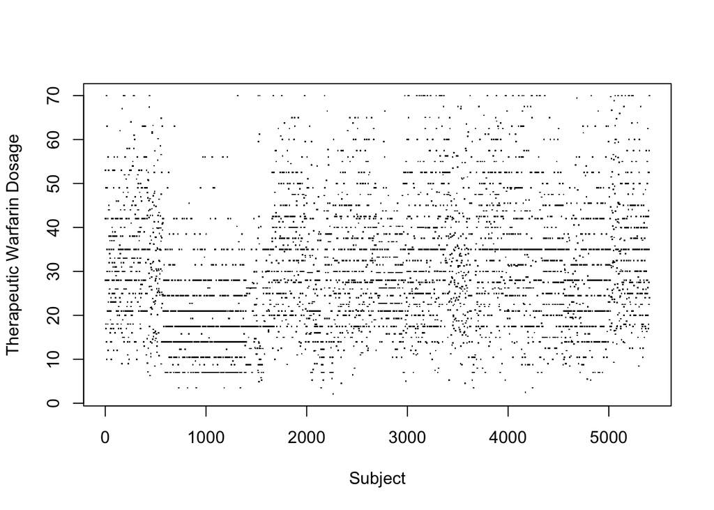

```r
library(ggplot2)
library(graphics)
#CLEAN DATA

#READ IN DATA FROM DATASET IN REPOSITORY
my.url <- getURL("https://raw.githubusercontent.com/misraj/pharmgkb_project/master/warfarin_data.txt") #Getting warfarin data
warfarin <- read.delim(text = my.url, header=TRUE)

#Filter out observations that did not have a thereapeutic dosage data available
warfarin <- filter(warfarin, complete.cases(Therapeutic.Dose))

#filter out observations whose therapeutic dosage  mg/week is < 70, because usually the maximum dosage is 10 mg a day. Being able to detect risks for individuals who need higher dosages is a much more complicated task
warfarin <- filter(warfarin, Therapeutic.Dose <= 70)
#Plot dosage data
N = length(warfarin$Subject.ID) #number of subjects
V = length(names(warfarin))  #number of variables
plot(seq(1:N), warfarin$Therapeutic.Dose, xlab  = "Subject", ylab = "Therapeutic Warfarin Dosage", pch = ".")
```

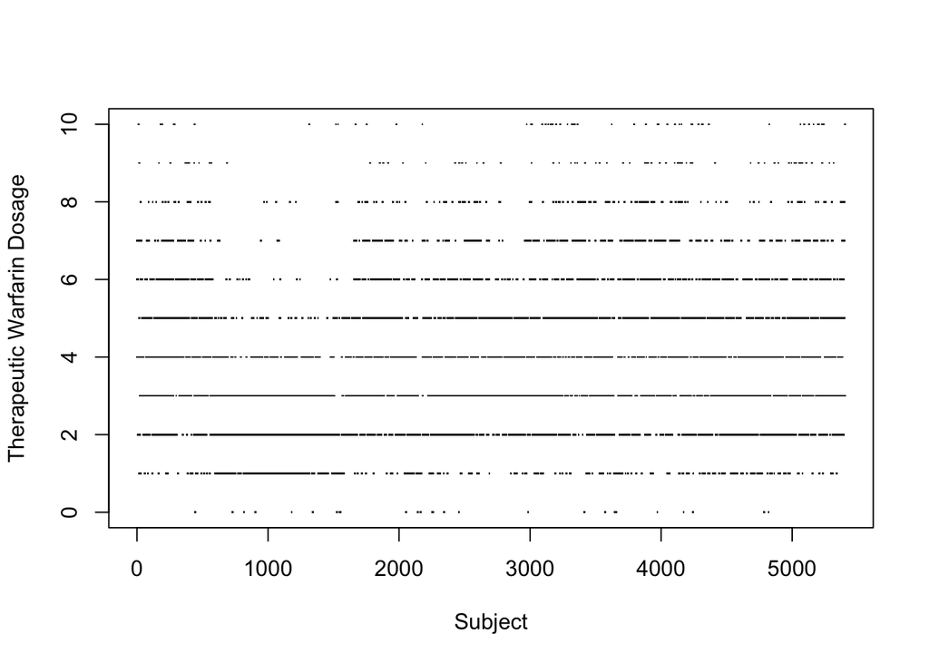

```r
# To make this problem a bit more solvable, I divided the total dosage/week by 7 to get an average daily dose.
warfarin$Therapeutic.Dose <- as.integer(warfarin$Therapeutic.Dose/7)
plot(seq(1:N), warfarin$Therapeutic.Dose, xlab  = "Subject", ylab = "Therapeutic Warfarin Dosage", pch = ".")
```

```r
#Remove Variables that give us 0 information. No data reported for this field.
warfarin<-dplyr::select(warfarin,-(Cerivastatin))
```

Perform univariate associations using linear regression and check for missing-ness.

```r
#Look at individual univariate associations
uni_reg <- data.frame(seq(1:V-2),seq(1:V-2))
colnames(uni_reg) <- c("Variable", "Pval")
#First two fields are sample and subject Id, so ignore for univarate analysis
for( i in 3:V){
  datas.glm <- lm(Therapeutic.Dose~ warfarin[,i:i], data=warfarin)
  pv <-summary(datas.glm)$coefficients[2,4]
  uni_reg[i-2,1] <-names(warfarin)[i]
  uni_reg[i-2,2] <-pv
}

#Sort by most significantly associated
uni_reg <- arrange(uni_reg,Pval)
significant <- filter(uni_reg, Pval < 0.05)
significant

# About 41 variables independently are significantly associated with therapeutic dosage
#But we cannot do a linear regression model if there are missing data so we need to filter the data more

#Looking at missingness rate
missingness_feature <- rep(0, V)
for(i in 1:V){
  table <-table(is.na(warfarin[,i]))
  if(length(table) == 1){
    missingness_feature[i] = table/N
  }
  else{
    missingness_feature[i] = table[1]/N
  }
}
miss_feature<- data.frame(names(warfarin),missingness_feature)
miss_feature<- arrange(miss_feature, desc(missingness_feature))
#How many patients have this information?
set_n <- miss_feature$missingness_feature * N
miss_feature <- data.frame(miss_feature, set_n)

#Check missingness of patients
missingness_subjects <- rep(0,N)
for(i in 1:N){
  table <- table(is.na(warfarin[i,]))
  if(length(table) == 1){
    missingness_subjects[i] = table/V
  }
  else{
    missingness_subjects[i] = table[1]/V
  }
}
miss_subject <- data.frame(rownames(warfarin),missingness_subjects)
miss_subject <- arrange(miss_subject, desc(missingness_subjects))

#No patients should be thrown out.
```

[output not shown]

The dataset was filtered based on the combined list of significant univariate associations and missing-ness. The cut off for a significant association was a p-value of 1e-05. Filtering stopped as soon as we had 500 subjects to avoid training and testing on an underpowered study. However, there was no power calculation performed for this analysis.

```r
#Filter dataset based on the combined list of missingness and significant univariate associations
#call new dataset warfarin1
warfarin1 <- filter(warfarin, complete.cases(Weight))
warfarin1 <- filter(warfarin1, complete.cases(Height))
warfarin1 <- filter(warfarin1, complete.cases(Race.OMB))
warfarin1 <- filter(warfarin1, complete.cases(VKORC1.4_consensus))
warfarin1 <- filter(warfarin1, complete.cases(VKORC1.1_consensus))
warfarin1 <- filter(warfarin1, complete.cases(VKORC1.3_consensus))
warfarin1 <- filter(warfarin1, complete.cases(INR.Reported))
warfarin1 <- filter(warfarin1, complete.cases(VKORC1.6_consensus))
warfarin1 <- filter(warfarin1, complete.cases(Site))
warfarin1 <- filter(warfarin1, complete.cases(VKORC1.5))
warfarin1 <- filter(warfarin1, complete.cases(Amiodarone))
warfarin1 <- filter(warfarin1, complete.cases(Race.Reported))
warfarin1 <- filter(warfarin1, complete.cases(Gender))
warfarin1 <- filter(warfarin1, complete.cases(Genotyped.QC3.Cyp2C9))
warfarin1 <- filter(warfarin1, complete.cases(Genotyped.QC2.Cyp2C9))
warfarin1 <- filter(warfarin1, complete.cases(CYP2C9_consensus))
warfarin1 <- filter(warfarin1, complete.cases(VKORC1.7_QC))
```

Body mass index (BMI) variable was calculated and classified based on the classification reported by the National Heart, Lung, and Blood Institute. The new BMI variable was added to the filtered warfarin dataset.

```r
#Calculate BMI data
bmi <- rep(0,length(warfarin1$Weight))
for(i in 1:length(warfarin1$Weight)){
  h <- warfarin1$Height[i]/100
  den <- h *h
  bmi[i] <- warfarin1$Weight[i]/ den
  if(bmi[i] < 18.5){
    bmi[i] <- 1
  }
  else if(bmi[i] >=18.5 && bmi[i] <24.9 ){
    bmi[i] <- 2
  }
  else if(bmi[i] >= 25.0 && bmi[i] < 29.9 ){
    bmi[i] <- 3
  }
  else if(bmi[i] >=30.0 && bmi[i] <34.9 ){
    bmi[i] <- 4
  }
  else if(bmi[i] >=35.0 && bmi[i] <39.9 ){
    bmi[i] <- 5
  }
  else{
    bmi[i] <- 6
  }
}

warfarin1 <- cbind(warfarin1, bmi)
warfarin1 <- mutate(warfarin1, bmi = factor(bmi, levels=c(1, 2,3,4,5,6), labels=c("underweight", "normal", "overweight", "obesity1", "obesity2", "obesity3")))
```

Create the final, clean dataset.

```r
#Change variables to factors, (this was causing errors when contrasting varriables in the linear regression)
warfarin1$Site = as.factor(warfarin1$Site)
warfarin1$Weight = as.factor(warfarin1$Weight)
warfarin1$Height = as.factor(warfarin1$Height)
warfarin1$INR.Reported = as.factor(warfarin1$INR.Reported)


warfarin1 <- dplyr::select(warfarin1, Subject.ID, Sample.ID, Site, Race.OMB,Race.Reported, Gender, Weight, Height,bmi, VKORC1.4_consensus,VKORC1.1_consensus,VKORC1.3_consensus,INR.Reported,VKORC1.6_consensus, VKORC1.5, Amiodarone, Combined.QC4.CYP2C9,  Genotyped.QC3.Cyp2C9, Genotyped.QC2.Cyp2C9,  VKORC1.1_QC,VKORC1.2_QC,VKORC1.3_QC,VKORC1.4_QC,VKORC1.5_QC,VKORC1.6_QC,VKORC1.7_QC,Age,Cyp2C9,CYP2C9_consensus, Reached.Stable.Dose,Therapeutic.Dose)


#Mutate data so that there values are all factors
###Mutate/Change values to factors#######
warfarin1 <- mutate(warfarin1, Amiodarone = factor(Amiodarone, levels=c(0, 1), labels=c("no", "yes")))
```

A few exploratory analysis was done to answer a few questions regarding some of the clinical and genetic data of the new set. For example, are there more males than females? What is the age, height, weight, BMI distribution? A handful of variables were explored and bar graphs are shown below.

### Results

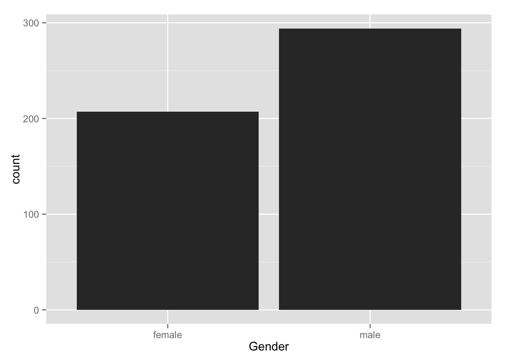

```r
#Exploratory analysis

ggplot(warfarin1, aes(x = Gender)) + geom_bar(stat = "bin")
```

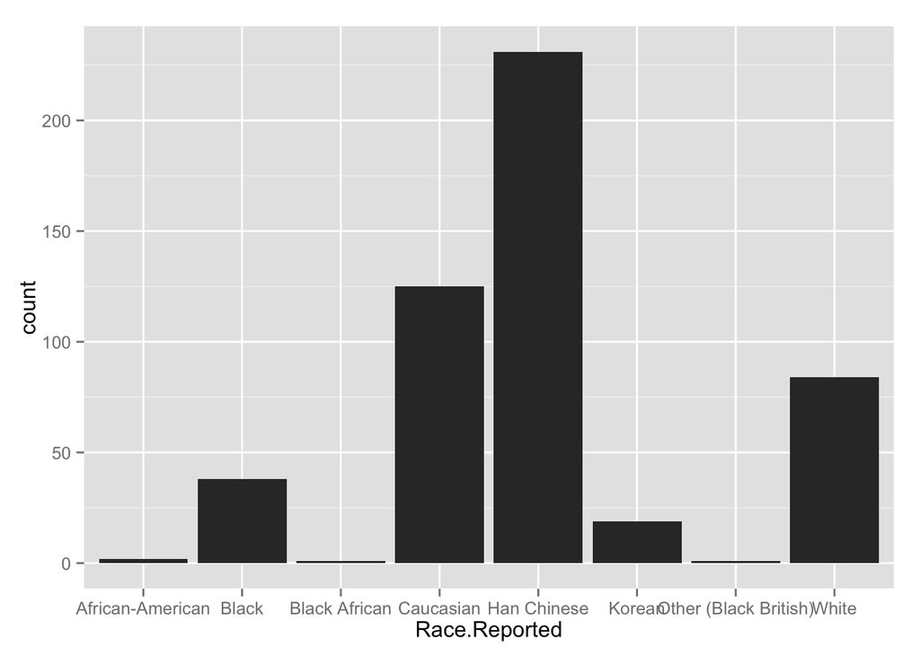

```r
ggplot(warfarin1, aes(x = Race.Reported)) + geom_bar(stat = "bin")
```

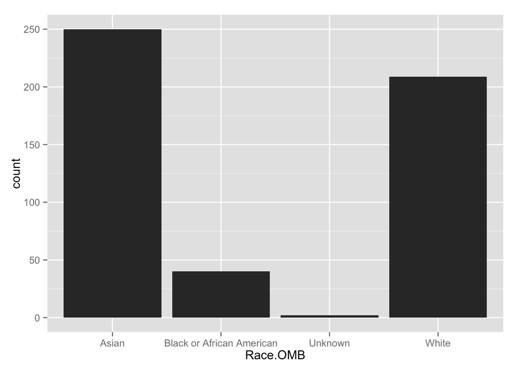

```r
ggplot(warfarin1, aes(x = Race.OMB)) + geom_bar(stat = "bin")
```

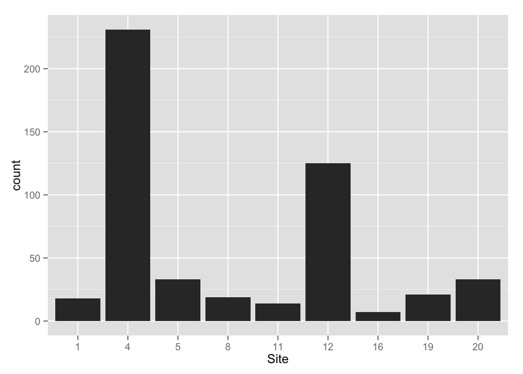

```r
ggplot(warfarin1, aes(x = Site)) + geom_bar(stat = "bin")
```

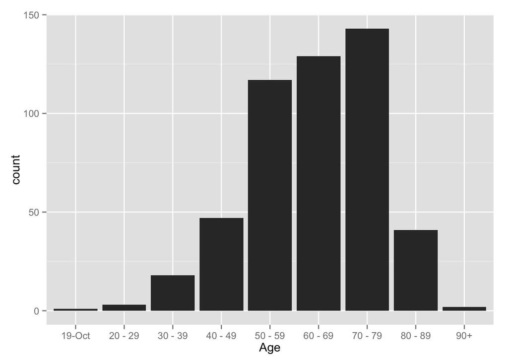

```r
ggplot(warfarin1, aes(x = Age)) + geom_bar(stat = "bin")
```

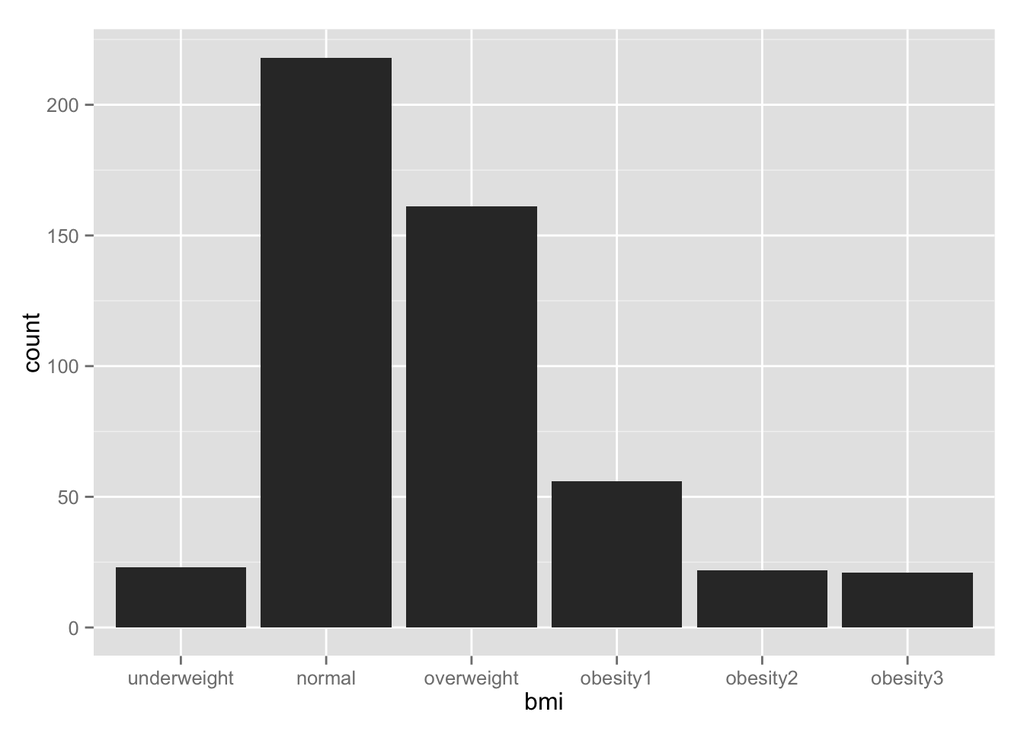

```r
ggplot(warfarin1, aes(x = bmi)) + geom_bar(stat = "bin")
```

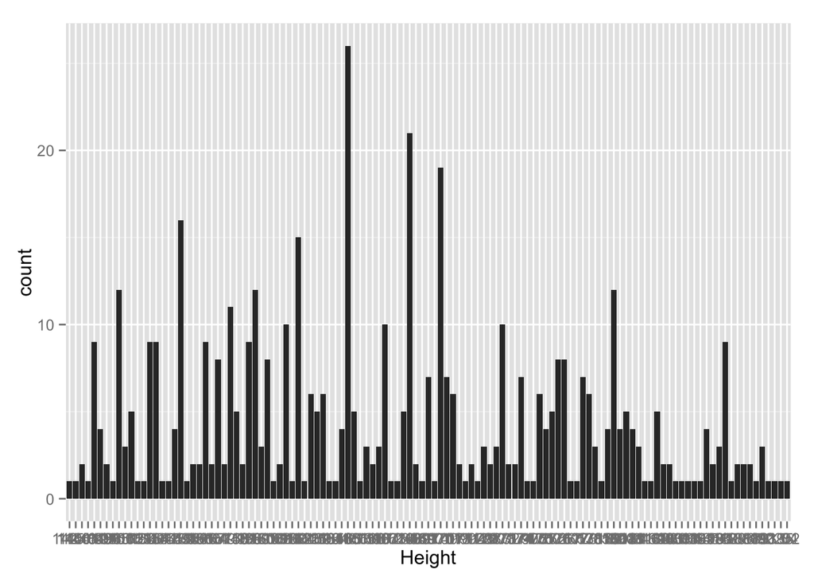

```r
ggplot(warfarin1, aes(x = Height)) + geom_bar(stat = "bin")
```

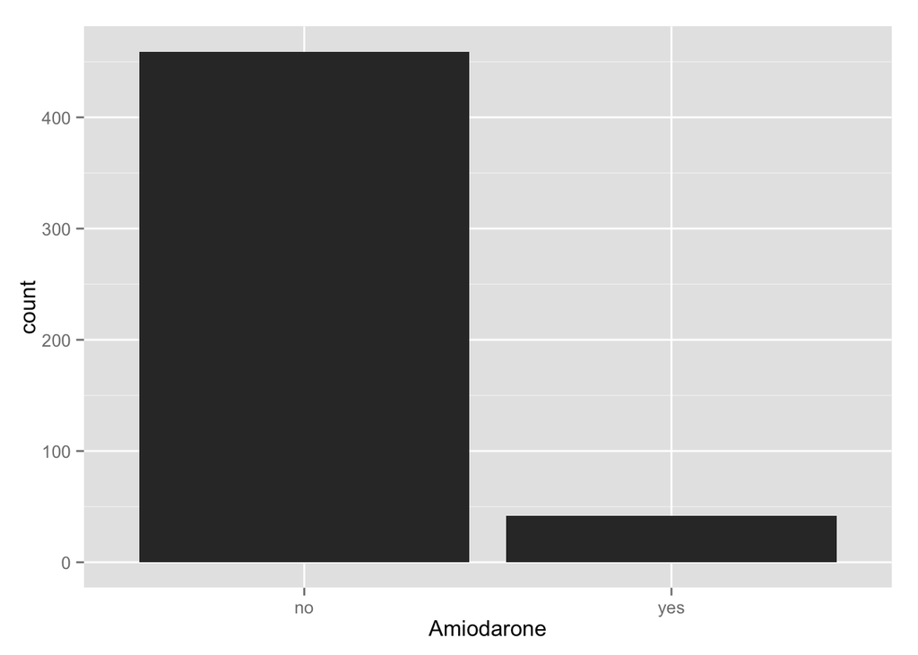

```r
ggplot(warfarin1, aes(x = Amiodarone)) + geom_bar(stat = "bin")
```

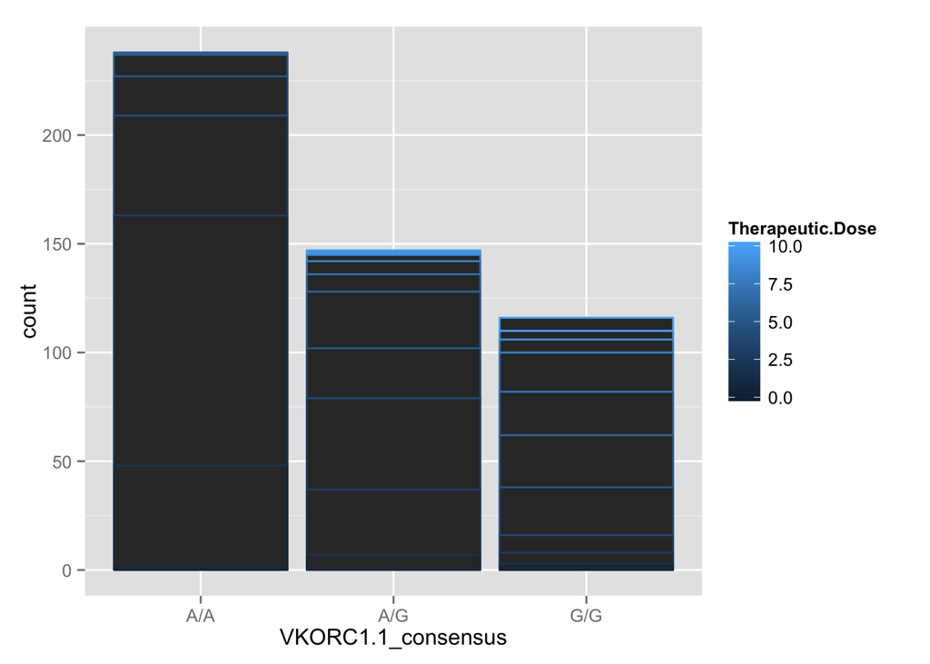

```r
#Looking at the variant rs9923231
#If interested in the other variants, there  is VKORC1.3_consensus, VKORC1.4_consensus,VKORC1.6_consensus,VKORC1.5, VKORC1.7_consensus(See variable code in the PharmGKB_Data.DOC)
ggplot(warfarin1, aes(x = VKORC1.1_consensus,group =Therapeutic.Dose , colour  = Therapeutic.Dose)) + geom_bar(stat = "bin")
```

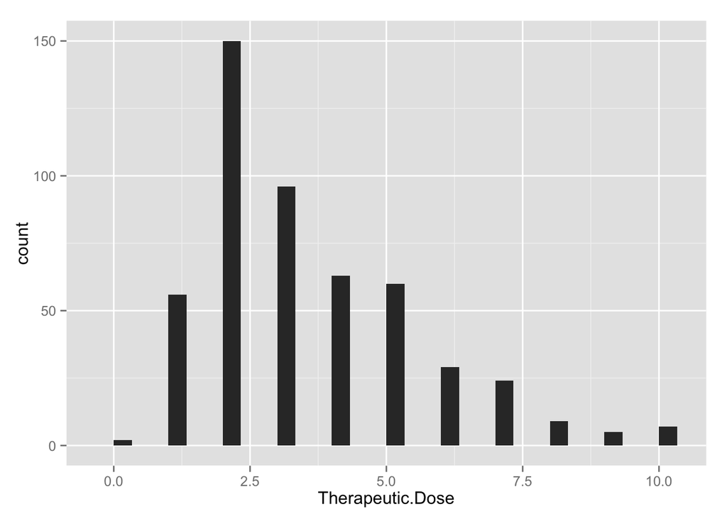

```r
ggplot(warfarin1, aes(x = Therapeutic.Dose)) + geom_bar(stat = "bin")
```

The newly filtered dataset was split into training set and validation set. Subject and sample ID were unique identifiers that were removed for regression analysis. The data sets were split into x and y variables, where y is the therapeutic dosage.

```r
#Get total points
n1 = length(warfarin1$Subject.ID)
#Split data into x.train, x.test, y.train, and y.test
train_rows1 <- sample(1:n1, .66*n1)
warf.train1 <- warfarin1[train_rows1, ]
warf.test1 <- warfarin1[-train_rows1, ]
dose.train1 <- warfarin1$Therapeutic.Dose[train_rows1]
dose.test1 <- warfarin1$Therapeutic.Dose[-train_rows1]
#Get rid of y in dataset
warf.train1 <- dplyr::select(warf.train1, -(Therapeutic.Dose))
warf.test1 <- dplyr::select(warf.test1, -(Therapeutic.Dose))
#Get rid of ID, it will mess up stepwise regression: test and train
warf.test1 <- dplyr::select(warf.test1, -(Subject.ID))
warf.train1 <- dplyr::select(warf.train1, -(Subject.ID))
warf.test1 <- dplyr::select(warf.test1, -(Sample.ID))
warf.train1 <- dplyr::select(warf.train1, -(Sample.ID))
```

Stepwise regression was performed on the training set to implement feature selection for the final model.

```r
null = lm(dose.train1 ~ 1, data = warf.train1) #first variable
full = lm(dose.train1 ~ ., data = warf.train1) #all variables

#Line of code for model selection. Uncomment to see how it works.
#model_selection = step(null, scope=list(lower=null, upper=full), direction="both", criterion = "BIC")
```

The new model based on stepwise regression was tested on the training set, and on the validation set. After running the stepwise regression several times, different models were reported to be the best each time. For this project, I am reporting the best model without BMI variable and with BMI variable (based on AIC/BIC reported). Note that these models may be inconsistent with the output of the stepwise command reported above because the outcome changes slightly every time the function is implemented. The first model consisted of features including the VKORC1 variant rs9934438, a variable considering all variants of Cyp2C9, a variable for CYP2C9 variant rs1057910, age, weight, site, whether or not the patient takes amiodarone, and whether or not they reached stable dose. The second model included the same features except, instead of weight, BMI was included in the model as well as gender instead of whether or not subjects reached a stable dose, the variants rs9934438 and rs9923231 in the VKORC1 gene, and Cyp2C9 (variant at any of the positions they genotyped).

Evaluation on the training set for model 1, which does not include the BMI variable.

```r
###EVALUATION for Model 1: Before BMI variable was added###
#old model
warf_train1_reg <- lm(dose.train1 ~ VKORC1.3_consensus + Weight + Age + Cyp2C9 + Amiodarone + Genotyped.QC3.Cyp2C9 + Site + Reached.Stable.Dose, data= warf.train1)
#summary(warf_train1_reg)
best.warf_train1_reg <- predict.lm(warf_train1_reg,warf.train1, type = "response")
```

```r
best.warf_train1_reg <- round(best.warf_train1_reg, digits=0)
compare_warf_train1 <- data.frame(seq(1:length(warf.train1$Weight)),dose.train1,best.warf_train1_reg )
dose1<- arrange(compare_warf_train1, desc(dose.train1))
colnames(dose1)<- c("Subject","True","Predicted")
SSE1 = sum((dose1$Predicted - dose1$True)^2)
err1 = mean(abs(dose1$Predicted - dose1$True))
acc1 = dose1$Predicted - dose1$True
est1 = seq(1:length(dose1$Dose))
for( i in 1:length(acc1)){
  if (acc1[i] == 0){
    est1[i] = "correct"
  }
  else if(acc1[i] > 0){
   est1[i] = "overestimate"
  }
  else{
   est1[i] = "underestimate"
  }
}
dose1$Label = est1
#ggplot(data=dose1, aes(x= Predicted, y= True,colour = Label)) +
    geom_point( size=1, shape=21, fill="white")
```

```
## geom_point: na.rm = FALSE, shape = 21, size = 1, fill = white
## stat_identity:
## position_identity: (width = NULL, height = NULL)
```

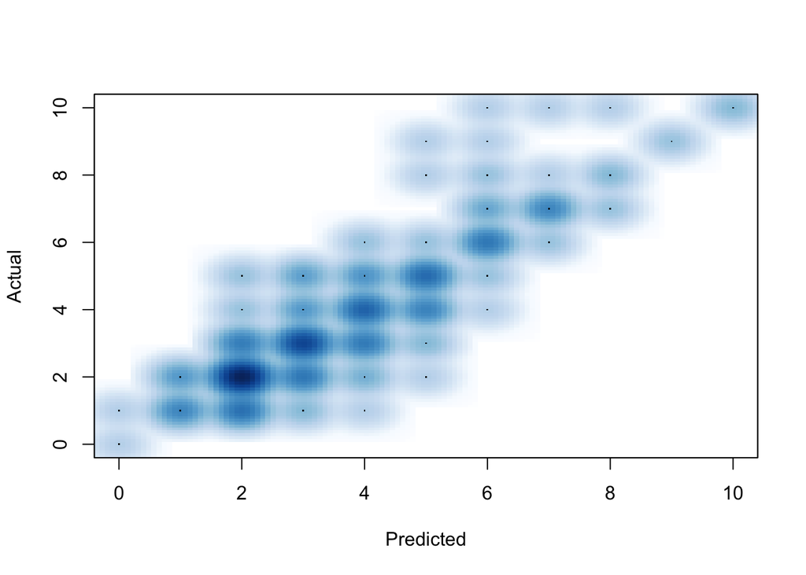

```r
smoothScatter(x= dose1$Predicted, y =  dose1$True, xlab = "Predicted", ylab = "Actual")
```

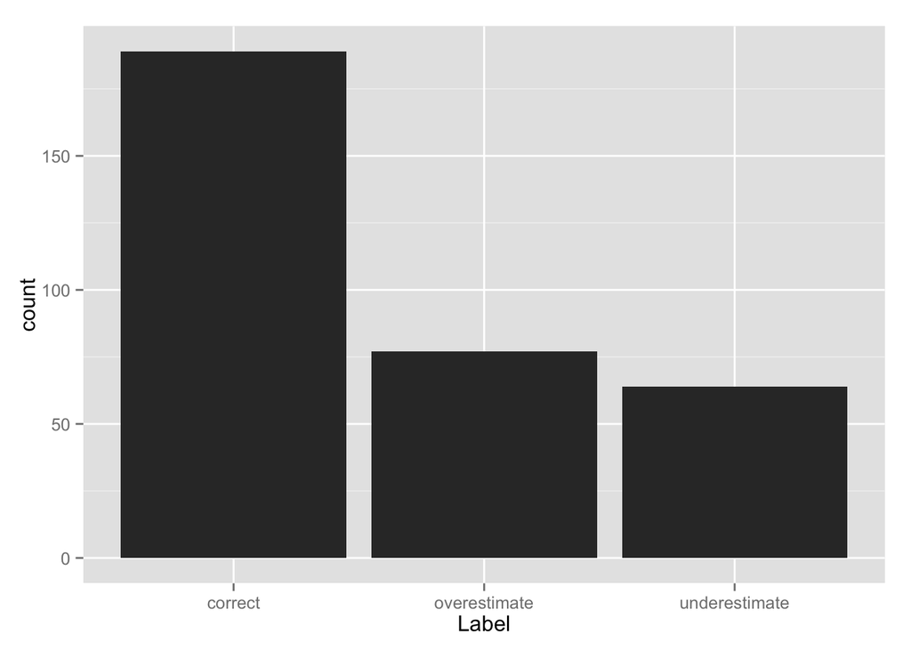

```r
ggplot(data=dose1, aes(x= Label)) + geom_bar()
```

Evaluation on the testing set for model 1, which does not include the BMI variable.

```r
###EVALUATION ON TESTING SET FOR MODEL 1 (PRE BMI)###
#old model
warf_test1_reg <- lm(dose.test1 ~ VKORC1.3_consensus + Weight + Age + Cyp2C9 + Amiodarone + Genotyped.QC3.Cyp2C9 + Site + Reached.Stable.Dose, data= warf.test1)
#summary(warf_test1_reg)
best.warf_test1_reg <- predict.lm(warf_test1_reg,warf.test1, type = "response")
```

```r
best.warf_test1_reg <-round(best.warf_test1_reg, digits = 0)
compare_warf_test1 <- data.frame(seq(1:length(warf.test1$Weight)),dose.test1,best.warf_test1_reg )
dose1.t<- arrange(compare_warf_test1, desc(dose.test1))
colnames(dose1.t)<- c("Subject","True","Predicted")
SSE1t = sum((dose1.t$Predicted - dose1.t$True)^2)
err1t = mean(abs(dose1.t$Predicted - dose1.t$True))
err.sd1t = sd(abs(dose1.t$Predicted - dose1.t$True))
avg_dose_predicted1t = mean(dose1.t$Predicted)
avg_dose_true1t = mean(dose1.t$True)
dose_pred.sd1t = sd(dose1.t$Predicted)
dose_true.sd1t = sd(dose1.t$True)
acc1t = dose1.t$Predicted - dose1.t$True
est1t = seq(1:length(dose1.t$Dose))
for( i in 1:length(acc1t)){
  if (acc1t[i] == 0){
    est1t[i] = "correct"
  }
  else if(acc1t[i] > 0){
    est1t[i] = "overestimate"
  }
  else{
    est1t[i] = "underestimate"
  }
}
dose1.t$Label = est1t
#ggplot(data=dose1.t, aes(x= Predicted, y= True,colour = Label)) +
  geom_point( size=1, shape=21, fill="white")
```

```
## geom_point: na.rm = FALSE, shape = 21, size = 1, fill = white
## stat_identity:
## position_identity: (width = NULL, height = NULL)
```

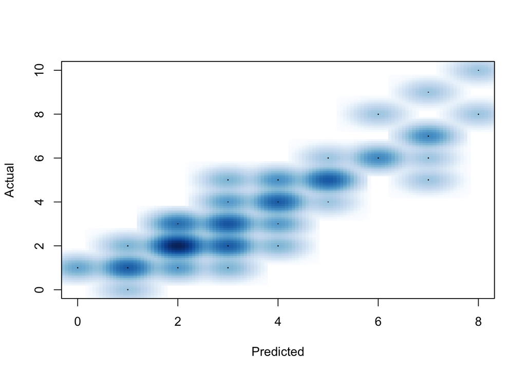

```r
smoothScatter(x= dose1.t$Predicted, y =  dose1.t$True, xlab = "Predicted", ylab = "Actual")
```

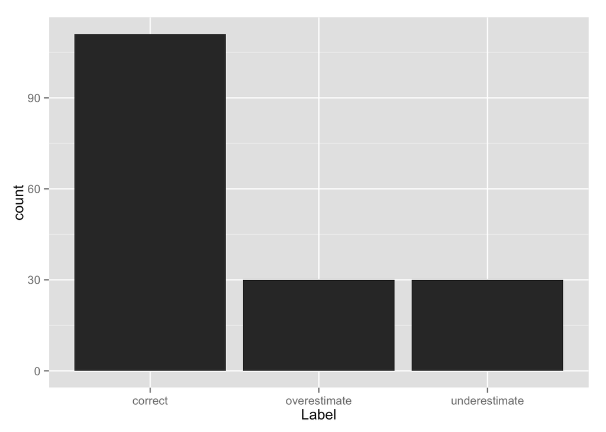

```r
ggplot(data=dose1.t, aes(x= Label)) + geom_bar()
```

Evaluation on the training set for model 2, which includes the BMI variable.

```r
###EVALUATION for MODEL 2 (WITH BMI VARIABLES) ON TRAINING###
warf_train1_reg <- lm(dose.train1 ~ VKORC1.3_consensus + Age + bmi + Cyp2C9 + Amiodarone + Site + VKORC1.1_QC + Gender, data= warf.train1)
best.warf_train1_reg <- predict.lm(warf_train1_reg,warf.train1, type = "response")
best.warf_train1_reg <- round(best.warf_train1_reg, digits=0)
compare_warf_train1 <- data.frame(seq(1:length(warf.train1$Weight)),dose.train1,best.warf_train1_reg )
dose1<- arrange(compare_warf_train1, desc(dose.train1))
colnames(dose1)<- c("Subject","True","Predicted")
SSE1 = sum((dose1$Predicted - dose1$True)^2)
err1 = mean(abs(dose1$Predicted - dose1$True))
acc1 = dose1$Predicted - dose1$True
est1 = seq(1:length(dose1$Dose))
for( i in 1:length(acc1)){
  if (acc1[i] == 0){
    est1[i] = "correct"
  }
  else if(acc1[i] > 0){
   est1[i] = "overestimate"
  }
  else{
   est1[i] = "underestimate"
  }
}
dose1$Label = est1
#ggplot(data=dose1, aes(x= Predicted, y= True,colour = Label)) +
    geom_point( size=1, shape=21, fill="white")
```

```
## geom_point: na.rm = FALSE, shape = 21, size = 1, fill = white
## stat_identity:
## position_identity: (width = NULL, height = NULL)
```

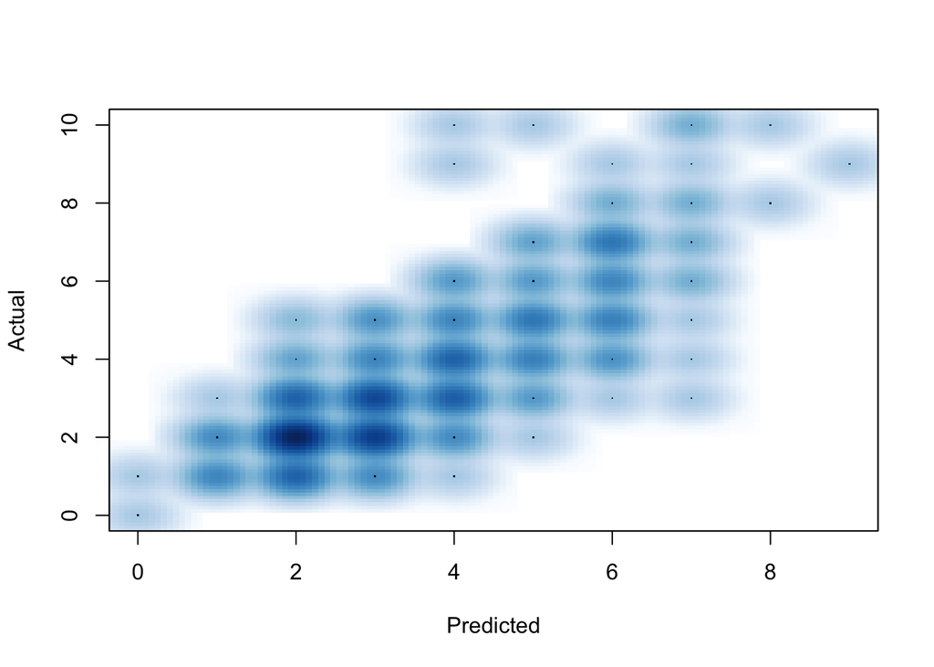

```r
smoothScatter(x= dose1$Predicted, y =  dose1$True, xlab = "Predicted", ylab = "Actual")
```

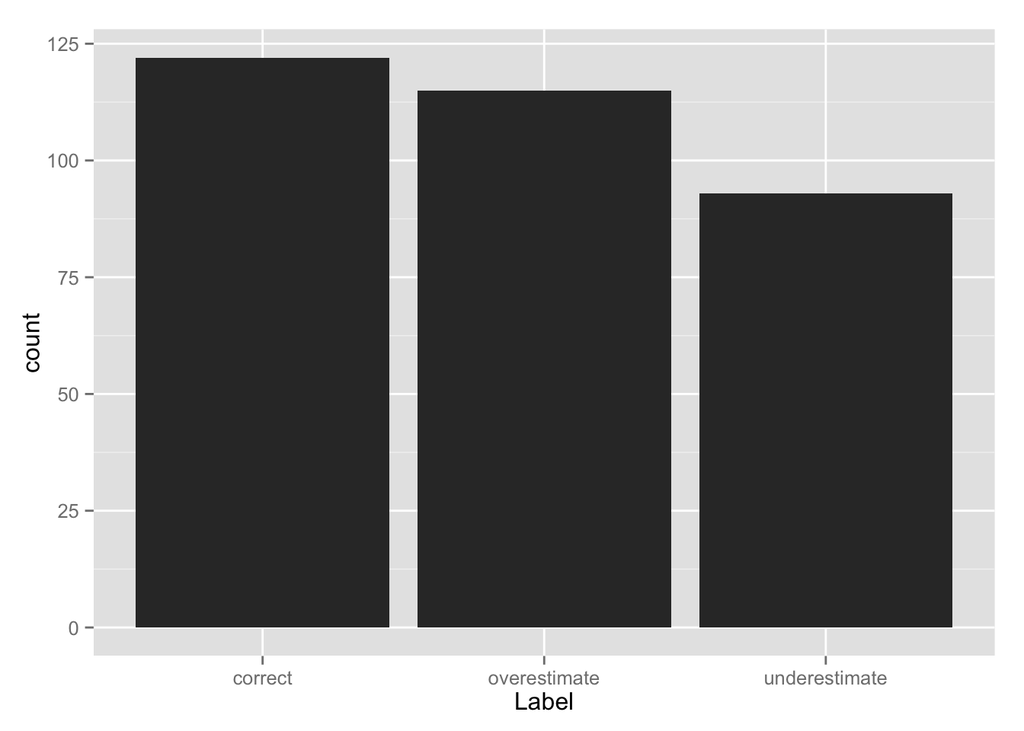

```r
ggplot(data=dose1, aes(x= Label)) + geom_bar()
```

Evaluation on the testing set for model 2, which includes the BMI variable.

```r
###EVALUATION ON TESTING SET FOR MODEL 2(WITH BMI)###
warf_test1_reg <- lm(dose.test1 ~ VKORC1.3_consensus + Age + bmi + Cyp2C9 + Amiodarone + Site + VKORC1.1_QC + Gender,data = warf.test1)
best.warf_test1_reg <- predict.lm(warf_test1_reg,warf.test1, type = "response")
best.warf_test1_reg <-round(best.warf_test1_reg, digits = 0)
compare_warf_test1 <- data.frame(seq(1:length(warf.test1$Weight)),dose.test1,best.warf_test1_reg )
dose1.t<- arrange(compare_warf_test1, desc(dose.test1))
colnames(dose1.t)<- c("Subject","True","Predicted")
SSE1t = sum((dose1.t$Predicted - dose1.t$True)^2)
err1t = mean(abs(dose1.t$Predicted - dose1.t$True))
err.sd1t = sd(abs(dose1.t$Predicted - dose1.t$True))
avg_dose_predicted1t = mean(dose1.t$Predicted)
avg_dose_true1t = mean(dose1.t$True)
dose_pred.sd1t = sd(dose1.t$Predicted)
dose_true.sd1t = sd(dose1.t$True)
acc1t = dose1.t$Predicted - dose1.t$True
est1t = seq(1:length(dose1.t$Dose))
for( i in 1:length(acc1t)){
  if (acc1t[i] == 0){
    est1t[i] = "correct"
  }
  else if(acc1t[i] > 0){
    est1t[i] = "overestimate"
  }
  else{
    est1t[i] = "underestimate"
  }
}
dose1.t$Label = est1t
#ggplot(data=dose1.t, aes(x= Predicted, y= True,colour = Label)) +
  geom_point( size=1, shape=21, fill="white")
```

```
## geom_point: na.rm = FALSE, shape = 21, size = 1, fill = white
## stat_identity:
## position_identity: (width = NULL, height = NULL)
```

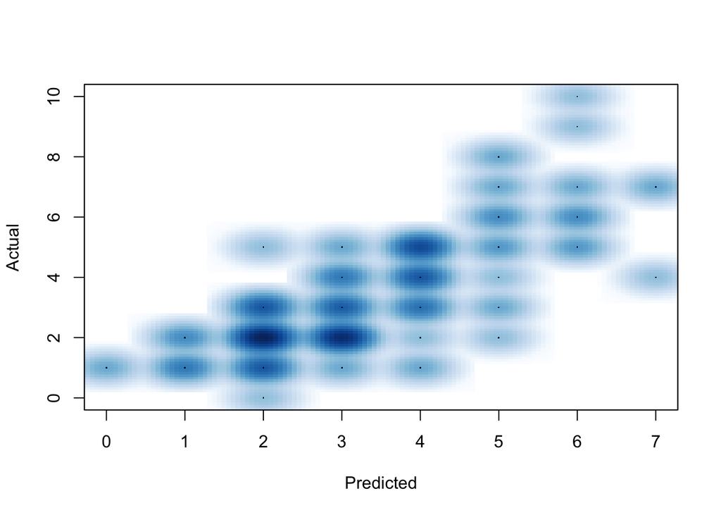

```r
smoothScatter(x= dose1.t$Predicted, y =  dose1.t$True, xlab = "Predicted", ylab = "Actual")
```

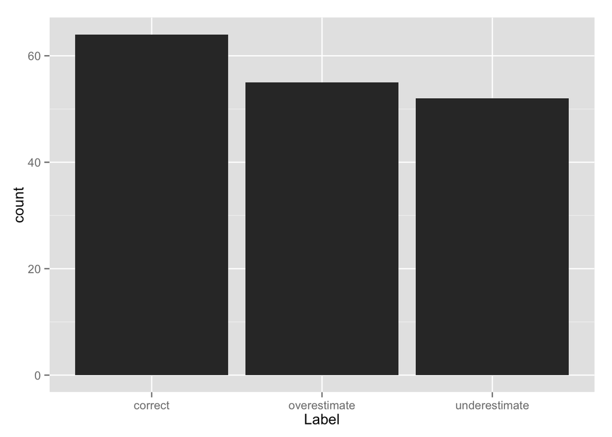

```r
ggplot(data=dose1.t, aes(x= Label)) + geom_bar()
```

As a sanity check, I was curious to see the same pattern regarding the variant rs9923231, to see if we are seeing the same (expected) pattern. The bar graph shown below is consistent with what we saw in the exploratory analysis, which was those who have both A alleles require smaller warfarin dosage.

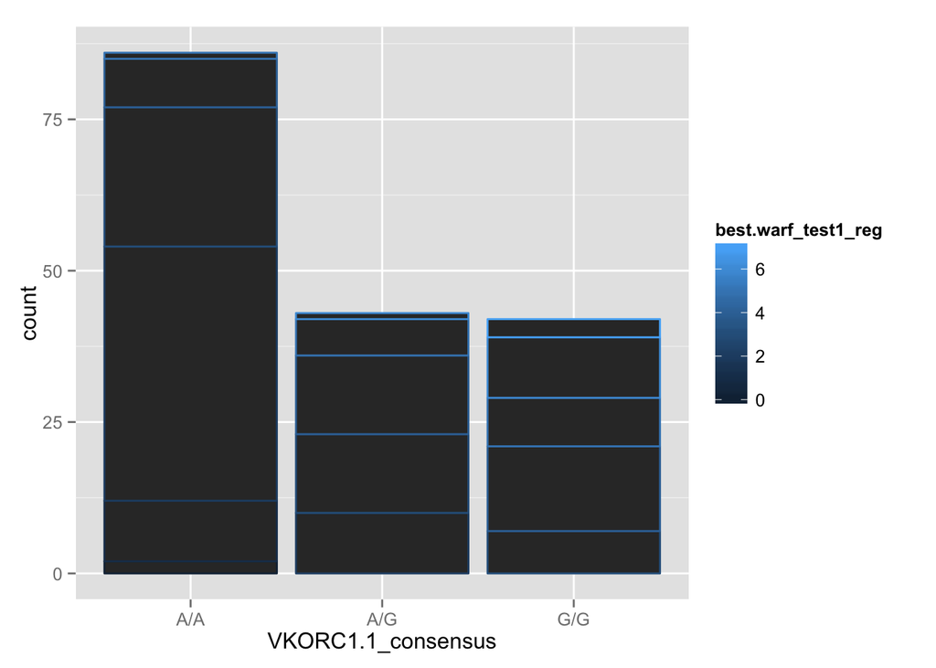

```r
warf = data.frame(warf.test1,best.warf_test1_reg)
ggplot(warf, aes(x = VKORC1.1_consensus,group =best.warf_test1_reg , colour  = best.warf_test1_reg)) + geom_bar(stat = "bin")
```